# Interactive 3D Graphics of PITCHf/x Data

Good thing I follow everything my current T.A. [Yihui Xie](http://yihui.name) does when he isn't grading my bayes homework. Otherwise, I wouldn't have known about the wonderful [rgl](http://cran.r-project.org/web/packages/rgl/index.html) package - and it's [seamless html integration via knitr](https://twitter.com/xieyihui/status/302513617906044930).

I am absolutely giddy over the features rgl will add to my recently released R package [pitchRx](http://cran.r-project.org/web/packages/pitchRx/). Note that this example depends on developmental version of [pitchRx on github](https://github.com/cpsievert/), so if you're on windows, install [RTools](http://cran.rstudio.com/bin/windows/Rtools/) before installing [devtools](http://cran.r-project.org/web/packages/devtools/index.html).

```r
library(devtools)  #must be installed first
library(knitr)  #I'm using version 1.1
install_github("pitchRx", "cpsievert")
library(pitchRx)
```

After pitchRx is loaded, I can bring in the sample dataset, then restrict to pitches thrown by Mariano Rivera's. Next, a simple call to `rglFX` automatically generates an interactive 3D scatterplot (hold and drag your mouse on the scatterplot below - you can also zoom in and out). **rgl** currently has no support for including legends, so `rglFX` also prints the appropriate hex color codes in your R console.

```r
data(pitches)
Rivera <- subset(pitches, pitcher_name == "Mariano Rivera")
rglFX(Rivera)
```

```
## [1] "Here is the coloring scheme for your plot. Use http://www.colorhexa.com/ to translate color codes."
##            pitch_types  colors
## 1    Fastball (cutter) #ff0000
## 2 Fastball (four-seam) #0000ff
```

[interactive chart not shown]

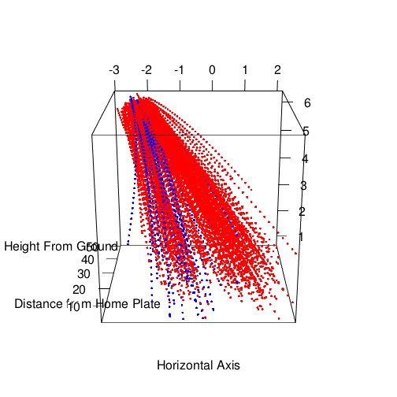

This is a really great way to visualize PITCHf/x. With this tool, we can easily examine any sequence of pitches - from any angle. This particular graphic portrays the deception of Rivera's cut fastball compared to his four-seam.

#### Authored by [Carson Sievert](http://cpsievert.github.com/home.html) via [R Markdown, knitr & RStudio](http://www.rstudio.com/ide/docs/authoring/using_markdown). Published by [GitHub Pages](http://pages.github.com/).